# Prediccion de varibles con Regresiòn lineal, multiple y logistica

Estalyn Duchi

2026-03-09

# Regresion lineal simple y Regresion Multiple

## Desarollar una descripcion clara del problema

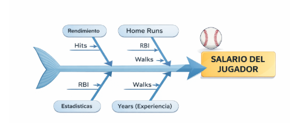

## Factores importantes

Años de experiencia (Years) – Los jugadores con más experiencia pueden tener salarios más altos.

Hits, Home Runs, RBI – Indicadores de desempeño ofensivo que reflejan la productividad del jugador.

Walks (Bases por bolas), At Bats (Turnos al bate) – Medidas de consistencia y oportunidad.

League y División – Categóricas que pueden capturar diferencias en contratos según la liga o división.

Edad – Puede influir en el salario según etapa de carrera.

## Proponer o refinar modelos

**Regresión lineal simple**

Primero, predecir el salario usando una sola estadística, por ejemplo, Home Runs.

Modelo :
$$Salary=β_0+β_1(HmRun)+ϵ$$

```r
library(ISLR)
data("Hitters")
modelo_simple <- lm(Salary ~ HmRun, data = Hitters)

summary(modelo_simple)
```

```
##
## Call:
## lm(formula = Salary ~ HmRun, data = Hitters)
##
## Residuals:
##     Min      1Q  Median      3Q     Max
## -748.73 -275.49  -79.27  184.72 1829.00
##
## Coefficients:
##             Estimate Std. Error t value Pr(>|t|)
## (Intercept)  330.594     43.551   7.591 5.64e-13 ***
## HmRun         17.671      2.995   5.900 1.13e-08 ***
## ---
## Signif. codes:  0 '***' 0.001 '**' 0.01 '*' 0.05 '.' 0.1 ' ' 1
##
## Residual standard error: 424.6 on 261 degrees of freedom
##   (59 observations deleted due to missingness)
## Multiple R-squared:  0.1177, Adjusted R-squared:  0.1143
## F-statistic: 34.81 on 1 and 261 DF,  p-value: 1.125e-08
```

```r
summary(modelo_simple)$r.squared
```

```
## [1] 0.1176683
```

Intercepto ($β_0$) = 330.594

Coeficiente de HmRun ($β_1$) = 17.671

p-value = 1.125e-08

$R^2$ = 0.1177

Esto ayuda a entender la relación directa entre una variable y el salario.

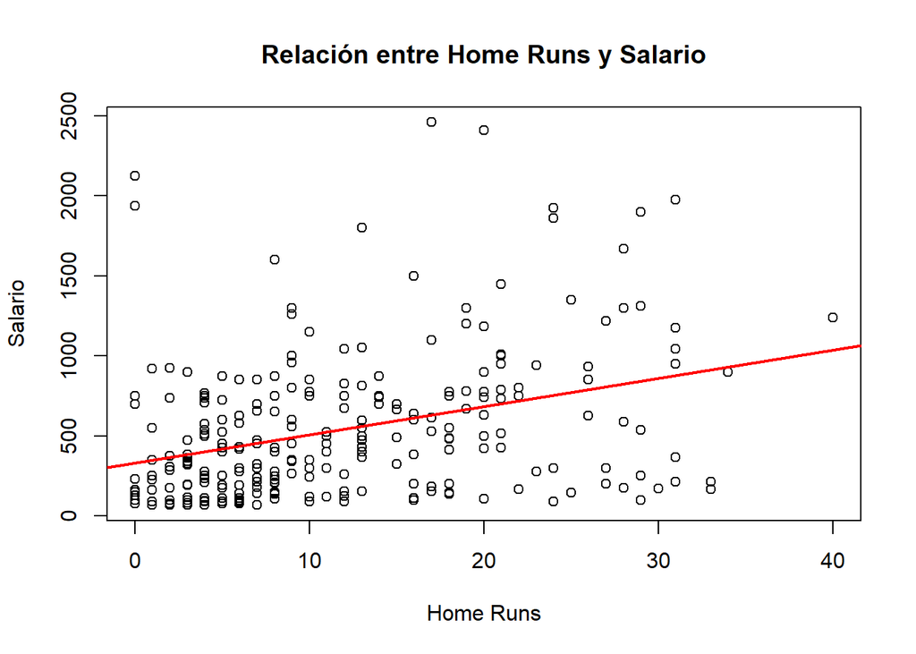

```r
plot(Hitters$HmRun, Hitters$Salary,
     xlab = "Home Runs",
     ylab = "Salario",
     main = "Relación entre Home Runs y Salario")

abline(modelo_simple, col = "red", lwd = 2)
```

**Interpretaciòn**

Se estimó un modelo de regresión lineal simple para analizar la relación entre el número de Home Runs (HmRun) y el salario de los jugadores. El modelo obtenido fue:
$$Salary=330.594+17.671(HmRun)$$
. Esto indica que, en promedio, por cada Home Run adicional el salario del jugador aumenta aproximadamente en 17.67 dòlares. El coeficiente asociado a la variable HmRun es estadísticamente significativo (p-value < 0.001), lo que demuestra que existe una relación positiva entre el rendimiento ofensivo medido por Home Runs y el salario de los jugadores.

Sin embargo, el coeficiente de determinación $𝑅^2$=0.1177 indica que el modelo explica solo el 11.77% de la variabilidad del salario, lo que sugiere que existen otros factores importantes que influyen en el salario de los jugadores. Por lo tanto, se recomienda utilizar modelos de regresión múltiple que incluyan más variables estadísticas para mejorar la capacidad predictiva del modelo.

**Regresión lineal múltiple**

Incluir varias variables independientes: Hits, Home Runs, RBI, Walks, Years, League, etc.

```r
modelo_multiple <- lm(Salary ~ Hits + HmRun + RBI + Walks + Years + League,
                      data = Hitters)

summary(modelo_multiple)
```

```
##
## Call:
## lm(formula = Salary ~ Hits + HmRun + RBI + Walks + Years + League,
##     data = Hitters)
##
## Residuals:
##     Min      1Q  Median      3Q     Max
## -754.10 -215.20  -50.17  103.67 2259.44
##
## Coefficients:
##              Estimate Std. Error t value Pr(>|t|)
## (Intercept) -265.1292    73.0443  -3.630 0.000343 ***
## Hits           2.4078     0.9296   2.590 0.010146 *
## HmRun          1.2127     5.3566   0.226 0.821068
## RBI            1.6707     2.5085   0.666 0.505985
## Walks          4.0279     1.2996   3.099 0.002156 **
## Years         33.6201     4.7396   7.093 1.28e-11 ***
## LeagueN       63.3762    45.5660   1.391 0.165473
## ---
## Signif. codes:  0 '***' 0.001 '**' 0.01 '*' 0.05 '.' 0.1 ' ' 1
##
## Residual standard error: 357.9 on 256 degrees of freedom
##   (59 observations deleted due to missingness)
## Multiple R-squared:  0.385,  Adjusted R-squared:  0.3706
## F-statistic: 26.71 on 6 and 256 DF,  p-value: < 2.2e-16
```

Interpretación del modelo

El modelo general es:

$$Salary=β_0+β_1(Hits)+β_2(HmRun)+β_3(RBI)+β_4(Walks)+β_5(Years)+β_6(League)$$

Se pueden usar métodos de selección de variables como:

Forward selection (agregar variables una por una)

```r
modelo_forward <- step(lm(Salary ~ 1, data=Hitters),
                       scope = formula(lm(Salary ~ ., data=Hitters)),
                       direction = "forward")
```

```
## Start:  AIC=3215.77
## Salary ~ 1
##
##             Df Sum of Sq      RSS    AIC
## + CRBI       1  17139434 36179679 3115.8
## + CRuns      1  16881162 36437951 3117.6
## + CHits      1  16065140 37253973 3123.5
## + CAtBat     1  14759710 38559403 3132.5
## + CHmRun     1  14692193 38626920 3133.0
## + CWalks     1  12792622 40526491 3145.6
## + RBI        1  10771083 42548030 3158.4
## + Walks      1  10504833 42814280 3160.1
## + Hits       1  10260491 43058621 3161.6
## + Runs       1   9399158 43919955 3166.8
## + Years      1   8559105 44760007 3171.7
## + AtBat      1   8309469 45009644 3173.2
## + HmRun      1   6273967 47045145 3184.8
## + PutOuts    1   4814100 48505013 3192.9
## + Division   1   1976102 51343011 3207.8
## <none>                   53319113 3215.8
## + Assists    1     34497 53284615 3217.6
## + League     1     10876 53308237 3217.7
## + Errors     1      1555 53317558 3217.8
## + NewLeague  1       428 53318684 3217.8
##
## Step:  AIC=3115.78
## Salary ~ CRBI
##
##             Df Sum of Sq      RSS    AIC
## + Hits       1   5533119 30646560 3074.1
## + Runs       1   5176532 31003147 3077.2
## + Walks      1   4199733 31979946 3085.3
## + AtBat      1   4064585 32115095 3086.4
## + RBI        1   3308272 32871407 3092.6
## + PutOuts    1   3267035 32912644 3092.9
## + Division   1   1733887 34445793 3104.9
## + Years      1   1667339 34512340 3105.4
## + HmRun      1   1271587 34908092 3108.4
## + CRuns      1    354561 35825119 3115.2
## + Assists    1    346020 35833659 3115.2
```

[output cut: 167 more lines]

```
## Step:  AIC=3031.26
## Salary ~ CRBI + Hits + PutOuts + Division + AtBat + Walks + CWalks +
##     CRuns + CAtBat + Assists
##
##             Df Sum of Sq      RSS    AIC
## <none>                   24500402 3031.3
## + League     1    113056 24387345 3032.0
## + Runs       1     75900 24424501 3032.4
## + NewLeague  1     64712 24435690 3032.6
## + CHits      1     37564 24462838 3032.8
## + Errors     1     35264 24465138 3032.9
## + Years      1     19883 24480519 3033.0
## + CHmRun     1      4356 24496046 3033.2
## + HmRun      1      1189 24499212 3033.2
## + RBI        1       359 24500043 3033.2
```

```r
summary(modelo_forward)
```

```
##
## Call:
## lm(formula = Salary ~ CRBI + Hits + PutOuts + Division + AtBat +
##     Walks + CWalks + CRuns + CAtBat + Assists, data = Hitters)
##
## Residuals:
##     Min      1Q  Median      3Q     Max
## -939.11 -176.87  -34.08  130.90 1910.55
##
## Coefficients:
##               Estimate Std. Error t value Pr(>|t|)
## (Intercept)  162.53544   66.90784   2.429 0.015830 *
## CRBI           0.77431    0.20961   3.694 0.000271 ***
## Hits           6.91802    1.64665   4.201 3.69e-05 ***
## PutOuts        0.29737    0.07444   3.995 8.50e-05 ***
## DivisionW   -112.38006   39.21438  -2.866 0.004511 **
## AtBat         -2.16865    0.53630  -4.044 7.00e-05 ***
## Walks          5.77322    1.58483   3.643 0.000327 ***
## CWalks        -0.83083    0.26359  -3.152 0.001818 **
## CRuns          1.40825    0.39040   3.607 0.000373 ***
## CAtBat        -0.13008    0.05550  -2.344 0.019858 *
## Assists        0.28317    0.15766   1.796 0.073673 .
## ---
## Signif. codes:  0 '***' 0.001 '**' 0.01 '*' 0.05 '.' 0.1 ' ' 1
##
## Residual standard error: 311.8 on 252 degrees of freedom
##   (59 observations deleted due to missingness)
## Multiple R-squared:  0.5405, Adjusted R-squared:  0.5223
## F-statistic: 29.64 on 10 and 252 DF,  p-value: < 2.2e-16
```

Backward elimination (eliminar variables irrelevantes)

```r
modelo_backward <- step(lm(Salary ~ ., data=Hitters),
                        direction = "backward")
```

```
## Start:  AIC=3046.02
## Salary ~ AtBat + Hits + HmRun + Runs + RBI + Walks + Years +
##     CAtBat + CHits + CHmRun + CRuns + CRBI + CWalks + League +
##     Division + PutOuts + Assists + Errors + NewLeague
##
##             Df Sum of Sq      RSS    AIC
## - CHmRun     1      1138 24201837 3044.0
## - CHits      1      3930 24204629 3044.1
## - Years      1      7869 24208569 3044.1
## - NewLeague  1      9784 24210484 3044.1
## - RBI        1     16076 24216776 3044.2
## - HmRun      1     48572 24249272 3044.6
## - Errors     1     58324 24259023 3044.7
## - League     1     62121 24262821 3044.7
## - Runs       1     63291 24263990 3044.7
## - CRBI       1    135439 24336138 3045.5
## - CAtBat     1    159864 24360564 3045.8
## <none>                   24200700 3046.0
## - Assists    1    280263 24480963 3047.1
## - CRuns      1    374007 24574707 3048.1
## - CWalks     1    609408 24810108 3050.6
## - Division   1    834491 25035190 3052.9
## - AtBat      1    971288 25171987 3054.4
## - Hits       1    991242 25191941 3054.6
## - Walks      1   1156606 25357305 3056.3
## - PutOuts    1   1319628 25520328 3058.0
##
## Step:  AIC=3044.03
## Salary ~ AtBat + Hits + HmRun + Runs + RBI + Walks + Years +
##     CAtBat + CHits + CRuns + CRBI + CWalks + League + Division +
##     PutOuts + Assists + Errors + NewLeague
##
##             Df Sum of Sq      RSS    AIC
## - Years      1      7609 24209447 3042.1
## - NewLeague  1     10268 24212106 3042.2
## - CHits      1     14003 24215840 3042.2
## - RBI        1     14955 24216793 3042.2
## - HmRun      1     52777 24254614 3042.6
## - Errors     1     59530 24261367 3042.7
## - League     1     63407 24265244 3042.7
```

[output cut: 164 more lines]

```
## Salary ~ AtBat + Hits + Walks + CAtBat + CRuns + CRBI + CWalks +
##     Division + PutOuts + Assists
##
##            Df Sum of Sq      RSS    AIC
## <none>                  24500402 3031.3
## - Assists   1    313650 24814051 3032.6
## - CAtBat    1    534156 25034558 3034.9
## - Division  1    798473 25298875 3037.7
## - CWalks    1    965875 25466276 3039.4
## - CRuns     1   1265082 25765484 3042.5
## - Walks     1   1290168 25790569 3042.8
## - CRBI      1   1326770 25827172 3043.1
## - PutOuts   1   1551523 26051925 3045.4
## - AtBat     1   1589780 26090181 3045.8
## - Hits      1   1716068 26216469 3047.1
```

```r
summary(modelo_backward)
```

```
##
## Call:
## lm(formula = Salary ~ AtBat + Hits + Walks + CAtBat + CRuns +
##     CRBI + CWalks + Division + PutOuts + Assists, data = Hitters)
##
## Residuals:
##     Min      1Q  Median      3Q     Max
## -939.11 -176.87  -34.08  130.90 1910.55
##
## Coefficients:
##               Estimate Std. Error t value Pr(>|t|)
## (Intercept)  162.53544   66.90784   2.429 0.015830 *
## AtBat         -2.16865    0.53630  -4.044 7.00e-05 ***
## Hits           6.91802    1.64665   4.201 3.69e-05 ***
## Walks          5.77322    1.58483   3.643 0.000327 ***
## CAtBat        -0.13008    0.05550  -2.344 0.019858 *
## CRuns          1.40825    0.39040   3.607 0.000373 ***
## CRBI           0.77431    0.20961   3.694 0.000271 ***
## CWalks        -0.83083    0.26359  -3.152 0.001818 **
## DivisionW   -112.38006   39.21438  -2.866 0.004511 **
## PutOuts        0.29737    0.07444   3.995 8.50e-05 ***
## Assists        0.28317    0.15766   1.796 0.073673 .
## ---
## Signif. codes:  0 '***' 0.001 '**' 0.01 '*' 0.05 '.' 0.1 ' ' 1
##
## Residual standard error: 311.8 on 252 degrees of freedom
##   (59 observations deleted due to missingness)
## Multiple R-squared:  0.5405, Adjusted R-squared:  0.5223
## F-statistic: 29.64 on 10 and 252 DF,  p-value: < 2.2e-16
```

Stepwise selection (combinación de ambas)

```r
modelo_stepwise <- step(lm(Salary ~ ., data=Hitters),
                        direction = "both")
```

```
## Start:  AIC=3046.02
## Salary ~ AtBat + Hits + HmRun + Runs + RBI + Walks + Years +
##     CAtBat + CHits + CHmRun + CRuns + CRBI + CWalks + League +
##     Division + PutOuts + Assists + Errors + NewLeague
##
##             Df Sum of Sq      RSS    AIC
## - CHmRun     1      1138 24201837 3044.0
## - CHits      1      3930 24204629 3044.1
## - Years      1      7869 24208569 3044.1
## - NewLeague  1      9784 24210484 3044.1
## - RBI        1     16076 24216776 3044.2
## - HmRun      1     48572 24249272 3044.6
## - Errors     1     58324 24259023 3044.7
## - League     1     62121 24262821 3044.7
## - Runs       1     63291 24263990 3044.7
## - CRBI       1    135439 24336138 3045.5
## - CAtBat     1    159864 24360564 3045.8
## <none>                   24200700 3046.0
## - Assists    1    280263 24480963 3047.1
## - CRuns      1    374007 24574707 3048.1
## - CWalks     1    609408 24810108 3050.6
## - Division   1    834491 25035190 3052.9
## - AtBat      1    971288 25171987 3054.4
## - Hits       1    991242 25191941 3054.6
## - Walks      1   1156606 25357305 3056.3
## - PutOuts    1   1319628 25520328 3058.0
##
## Step:  AIC=3044.03
## Salary ~ AtBat + Hits + HmRun + Runs + RBI + Walks + Years +
##     CAtBat + CHits + CRuns + CRBI + CWalks + League + Division +
##     PutOuts + Assists + Errors + NewLeague
##
##             Df Sum of Sq      RSS    AIC
## - Years      1      7609 24209447 3042.1
## - NewLeague  1     10268 24212106 3042.2
## - CHits      1     14003 24215840 3042.2
## - RBI        1     14955 24216793 3042.2
## - HmRun      1     52777 24254614 3042.6
## - Errors     1     59530 24261367 3042.7
## - League     1     63407 24265244 3042.7
```

[output cut: 209 more lines]

```
## + CHits      1     37564 24462838 3032.8
## + Errors     1     35264 24465138 3032.9
## + Years      1     19883 24480519 3033.0
## + CHmRun     1      4356 24496046 3033.2
## + HmRun      1      1189 24499212 3033.2
## + RBI        1       359 24500043 3033.2
## - CAtBat     1    534156 25034558 3034.9
## - Division   1    798473 25298875 3037.7
## - CWalks     1    965875 25466276 3039.4
## - CRuns      1   1265082 25765484 3042.5
## - Walks      1   1290168 25790569 3042.8
## - CRBI       1   1326770 25827172 3043.1
## - PutOuts    1   1551523 26051925 3045.4
## - AtBat      1   1589780 26090181 3045.8
## - Hits       1   1716068 26216469 3047.1
```

```r
summary(modelo_stepwise)
```

```
##
## Call:
## lm(formula = Salary ~ AtBat + Hits + Walks + CAtBat + CRuns +
##     CRBI + CWalks + Division + PutOuts + Assists, data = Hitters)
##
## Residuals:
##     Min      1Q  Median      3Q     Max
## -939.11 -176.87  -34.08  130.90 1910.55
##
## Coefficients:
##               Estimate Std. Error t value Pr(>|t|)
## (Intercept)  162.53544   66.90784   2.429 0.015830 *
## AtBat         -2.16865    0.53630  -4.044 7.00e-05 ***
## Hits           6.91802    1.64665   4.201 3.69e-05 ***
## Walks          5.77322    1.58483   3.643 0.000327 ***
## CAtBat        -0.13008    0.05550  -2.344 0.019858 *
## CRuns          1.40825    0.39040   3.607 0.000373 ***
## CRBI           0.77431    0.20961   3.694 0.000271 ***
## CWalks        -0.83083    0.26359  -3.152 0.001818 **
## DivisionW   -112.38006   39.21438  -2.866 0.004511 **
## PutOuts        0.29737    0.07444   3.995 8.50e-05 ***
## Assists        0.28317    0.15766   1.796 0.073673 .
## ---
## Signif. codes:  0 '***' 0.001 '**' 0.01 '*' 0.05 '.' 0.1 ' ' 1
##
## Residual standard error: 311.8 on 252 degrees of freedom
##   (59 observations deleted due to missingness)
## Multiple R-squared:  0.5405, Adjusted R-squared:  0.5223
## F-statistic: 29.64 on 10 and 252 DF,  p-value: < 2.2e-16
```

Considerar interacciones si algunas variables juntas afectan el salario más que individualmente.

**Regularización**

Técnicas como Ridge o Lasso regression pueden ayudar si hay muchas variables correlacionadas

```r
library(glmnet)
Hitters <- na.omit(Hitters)
x <- model.matrix(Salary ~ ., Hitters)[,-1]
y <- Hitters$Salary
```

La regresión Ridge reduce el tamaño de los coeficientes para evitar sobreajuste.

```r
Hitters <- na.omit(Hitters)
ridge_model <- glmnet(x, y, alpha = 0)
coef(ridge_model, s = 0.1)
```

[output not shown]

Elegir el mejor lambda (validación cruzada)

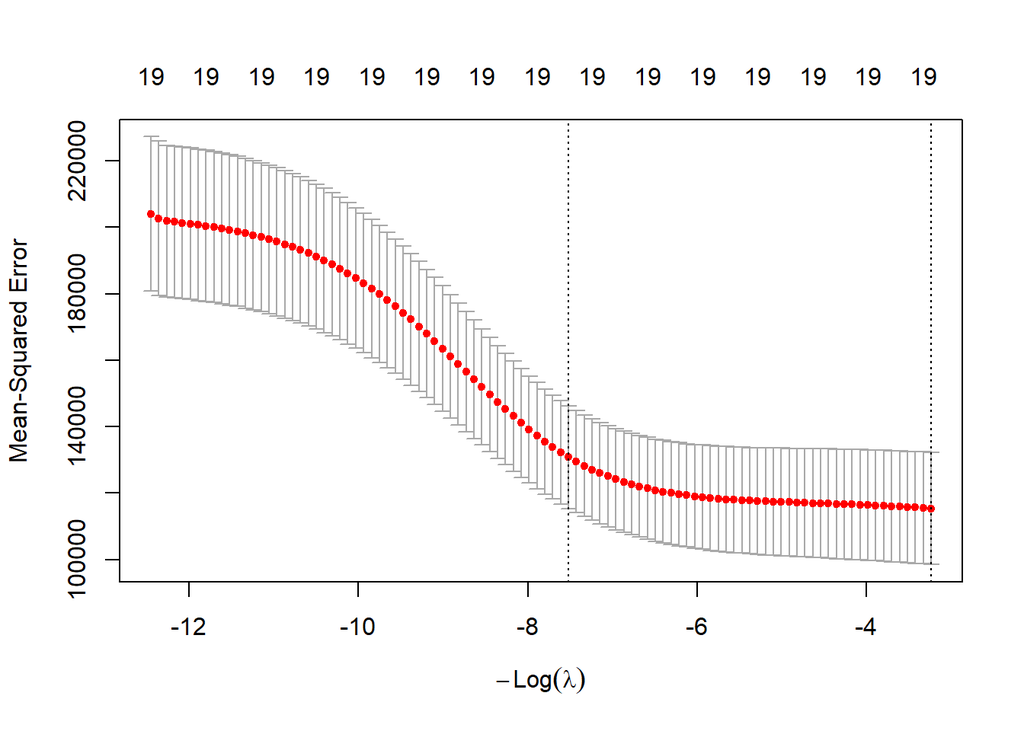

```r
cv_ridge <- cv.glmnet(x, y, alpha = 0)

plot(cv_ridge)
```

```r
cv_ridge$lambda.min
```

```
## [1] 25.52821
```

```r
coef(cv_ridge, s = "lambda.min")
```

```
## 20 x 1 sparse Matrix of class "dgCMatrix"
##                lambda.min
## (Intercept)  8.112693e+01
## AtBat       -6.815959e-01
## Hits         2.772312e+00
## HmRun       -1.365680e+00
## Runs         1.014826e+00
## RBI          7.130224e-01
## Walks        3.378558e+00
## Years       -9.066800e+00
## CAtBat      -1.199478e-03
## CHits        1.361029e-01
## CHmRun       6.979958e-01
## CRuns        2.958896e-01
## CRBI         2.570711e-01
## CWalks      -2.789666e-01
## LeagueN      5.321272e+01
## DivisionW   -1.228345e+02
## PutOuts      2.638876e-01
## Assists      1.698796e-01
## Errors      -3.685645e+00
## NewLeagueN  -1.810510e+01
```

Lasso Regression

Lasso puede reducir algunos coeficientes a cero, eliminando variables irrelevantes.

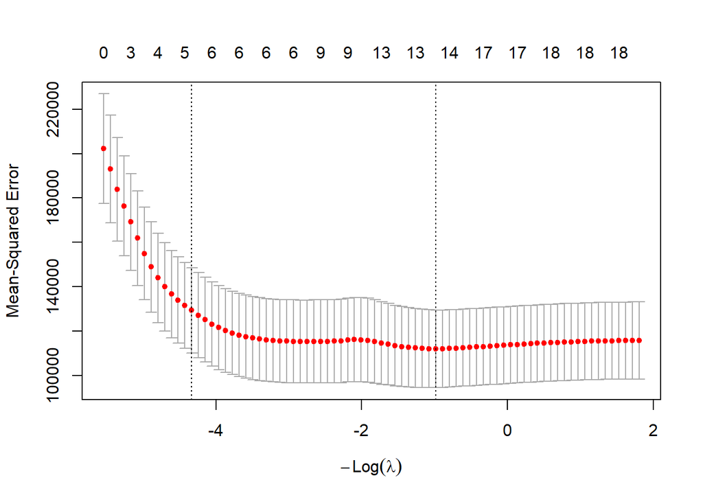

```r
lasso_model <- glmnet(x, y, alpha = 1)
cv_lasso <- cv.glmnet(x, y, alpha = 1)

plot(cv_lasso)
```

```r
cv_lasso$lambda.min
```

```
## [1] 2.674375
```

```r
coef(cv_lasso, s = "lambda.min")
```

```
## 20 x 1 sparse Matrix of class "dgCMatrix"
##               lambda.min
## (Intercept)  123.7520756
## AtBat         -1.5473426
## Hits           5.6608972
## HmRun          .
## Runs           .
## RBI            .
## Walks          4.7296908
## Years         -9.5958375
## CAtBat         .
## CHits          .
## CHmRun         0.5108207
## CRuns          0.6594856
## CRBI           0.3927505
## CWalks        -0.5291586
## LeagueN       32.0650811
## DivisionW   -119.2990171
## PutOuts        0.2724045
## Assists        0.1732025
## Errors        -2.0585083
## NewLeagueN     .
```

**Ridge Regression**

Reduce coeficientes.

Mantiene todas las variables.

Útil cuando hay multicolinealidad.

**Lasso Regression**

Reduce coeficientes.

Puede eliminar variables.

Sirve para selección automática de variables.

## Conducir experimentos y recolectar datos

Estamos utilizando una base propia de R de la libreria ISLR la base se llama Hitters.

```r
library(ISLR)
data(Hitters)
head(Hitters)
```

```
##                   AtBat Hits HmRun Runs RBI Walks Years CAtBat CHits CHmRun
## -Andy Allanson      293   66     1   30  29    14     1    293    66      1
## -Alan Ashby         315   81     7   24  38    39    14   3449   835     69
## -Alvin Davis        479  130    18   66  72    76     3   1624   457     63
## -Andre Dawson       496  141    20   65  78    37    11   5628  1575    225
## -Andres Galarraga   321   87    10   39  42    30     2    396   101     12
## -Alfredo Griffin    594  169     4   74  51    35    11   4408  1133     19
##                   CRuns CRBI CWalks League Division PutOuts Assists Errors
## -Andy Allanson       30   29     14      A        E     446      33     20
## -Alan Ashby         321  414    375      N        W     632      43     10
## -Alvin Davis        224  266    263      A        W     880      82     14
## -Andre Dawson       828  838    354      N        E     200      11      3
## -Andres Galarraga    48   46     33      N        E     805      40      4
## -Alfredo Griffin    501  336    194      A        W     282     421     25
##                   Salary NewLeague
## -Andy Allanson        NA         A
## -Alan Ashby        475.0         N
## -Alvin Davis       480.0         A
## -Andre Dawson      500.0         N
## -Andres Galarraga   91.5         N
## -Alfredo Griffin   750.0         A
```

**Preparación de datos:**

Eliminar filas con NA en salario.

```r
str(Hitters)
```

```
## 'data.frame':    322 obs. of  20 variables:
##  $ AtBat    : int  293 315 479 496 321 594 185 298 323 401 ...
##  $ Hits     : int  66 81 130 141 87 169 37 73 81 92 ...
##  $ HmRun    : int  1 7 18 20 10 4 1 0 6 17 ...
##  $ Runs     : int  30 24 66 65 39 74 23 24 26 49 ...
##  $ RBI      : int  29 38 72 78 42 51 8 24 32 66 ...
##  $ Walks    : int  14 39 76 37 30 35 21 7 8 65 ...
##  $ Years    : int  1 14 3 11 2 11 2 3 2 13 ...
##  $ CAtBat   : int  293 3449 1624 5628 396 4408 214 509 341 5206 ...
##  $ CHits    : int  66 835 457 1575 101 1133 42 108 86 1332 ...
##  $ CHmRun   : int  1 69 63 225 12 19 1 0 6 253 ...
##  $ CRuns    : int  30 321 224 828 48 501 30 41 32 784 ...
##  $ CRBI     : int  29 414 266 838 46 336 9 37 34 890 ...
##  $ CWalks   : int  14 375 263 354 33 194 24 12 8 866 ...
##  $ League   : Factor w/ 2 levels "A","N": 1 2 1 2 2 1 2 1 2 1 ...
##  $ Division : Factor w/ 2 levels "E","W": 1 2 2 1 1 2 1 2 2 1 ...
##  $ PutOuts  : int  446 632 880 200 805 282 76 121 143 0 ...
##  $ Assists  : int  33 43 82 11 40 421 127 283 290 0 ...
##  $ Errors   : int  20 10 14 3 4 25 7 9 19 0 ...
##  $ Salary   : num  NA 475 480 500 91.5 750 70 100 75 1100 ...
##  $ NewLeague: Factor w/ 2 levels "A","N": 1 2 1 2 2 1 1 1 2 1 ...
```

```r
summary(Hitters)
```

```
##      AtBat            Hits         HmRun            Runs
##  Min.   : 16.0   Min.   :  1   Min.   : 0.00   Min.   :  0.00
##  1st Qu.:255.2   1st Qu.: 64   1st Qu.: 4.00   1st Qu.: 30.25
##  Median :379.5   Median : 96   Median : 8.00   Median : 48.00
##  Mean   :380.9   Mean   :101   Mean   :10.77   Mean   : 50.91
##  3rd Qu.:512.0   3rd Qu.:137   3rd Qu.:16.00   3rd Qu.: 69.00
##  Max.   :687.0   Max.   :238   Max.   :40.00   Max.   :130.00
##
##       RBI             Walks            Years            CAtBat
##  Min.   :  0.00   Min.   :  0.00   Min.   : 1.000   Min.   :   19.0
##  1st Qu.: 28.00   1st Qu.: 22.00   1st Qu.: 4.000   1st Qu.:  816.8
##  Median : 44.00   Median : 35.00   Median : 6.000   Median : 1928.0
##  Mean   : 48.03   Mean   : 38.74   Mean   : 7.444   Mean   : 2648.7
##  3rd Qu.: 64.75   3rd Qu.: 53.00   3rd Qu.:11.000   3rd Qu.: 3924.2
##  Max.   :121.00   Max.   :105.00   Max.   :24.000   Max.   :14053.0
##
##      CHits            CHmRun           CRuns             CRBI
##  Min.   :   4.0   Min.   :  0.00   Min.   :   1.0   Min.   :   0.00
##  1st Qu.: 209.0   1st Qu.: 14.00   1st Qu.: 100.2   1st Qu.:  88.75
##  Median : 508.0   Median : 37.50   Median : 247.0   Median : 220.50
##  Mean   : 717.6   Mean   : 69.49   Mean   : 358.8   Mean   : 330.12
##  3rd Qu.:1059.2   3rd Qu.: 90.00   3rd Qu.: 526.2   3rd Qu.: 426.25
##  Max.   :4256.0   Max.   :548.00   Max.   :2165.0   Max.   :1659.00
##
##      CWalks        League  Division    PutOuts          Assists
##  Min.   :   0.00   A:175   E:157    Min.   :   0.0   Min.   :  0.0
##  1st Qu.:  67.25   N:147   W:165    1st Qu.: 109.2   1st Qu.:  7.0
##  Median : 170.50                    Median : 212.0   Median : 39.5
##  Mean   : 260.24                    Mean   : 288.9   Mean   :106.9
##  3rd Qu.: 339.25                    3rd Qu.: 325.0   3rd Qu.:166.0
##  Max.   :1566.00                    Max.   :1378.0   Max.   :492.0
##
##      Errors          Salary       NewLeague
##  Min.   : 0.00   Min.   :  67.5   A:176
##  1st Qu.: 3.00   1st Qu.: 190.0   N:146
##  Median : 6.00   Median : 425.0
##  Mean   : 8.04   Mean   : 535.9
##  3rd Qu.:11.00   3rd Qu.: 750.0
##  Max.   :32.00   Max.   :2460.0
##                  NA's   :59
```

```r
Hitters <- na.omit(Hitters)
sum(is.na(Hitters))
```

```
## [1] 0
```

**Exploración inicial:**

Graficar relaciones entre variables y salario para entender patrones.

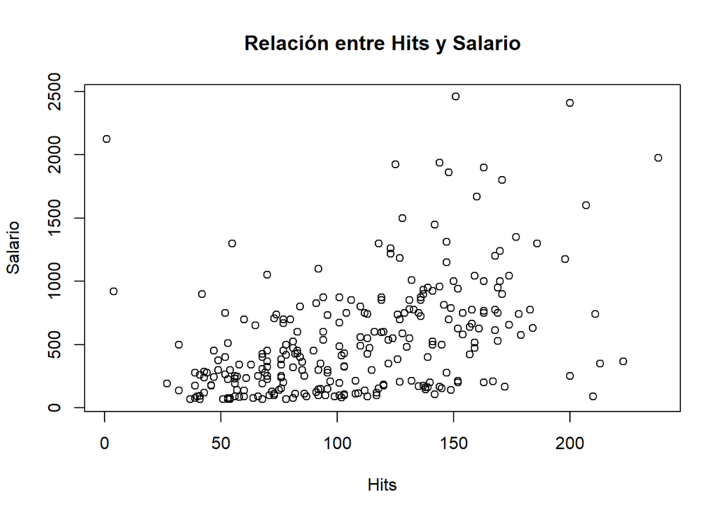

```r
plot(Hitters$Hits, Hitters$Salary,
     xlab="Hits",
     ylab="Salario",
     main="Relación entre Hits y Salario")
```

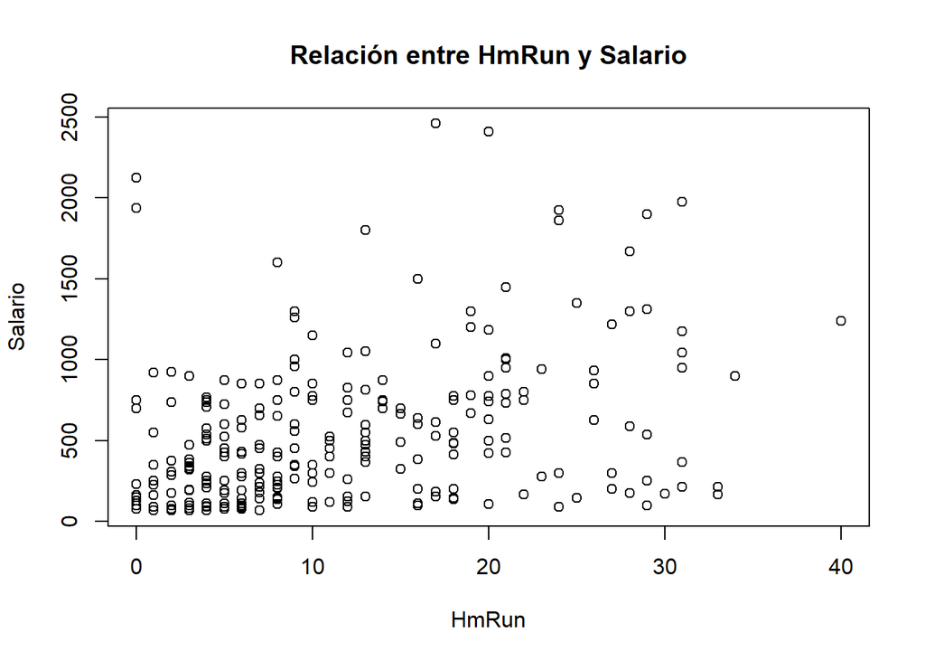

```r
plot(Hitters$HmRun, Hitters$Salary,
     xlab="HmRun",
     ylab="Salario",
     main="Relación entre HmRun y Salario")
```

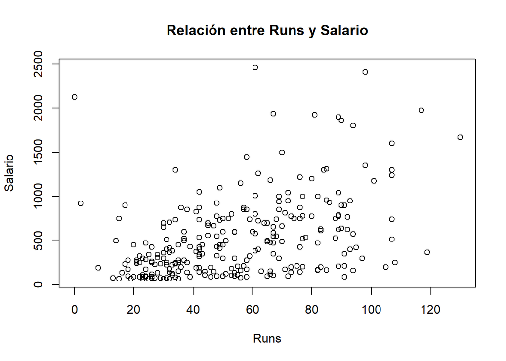

```r
plot(Hitters$Runs, Hitters$Salary,
     xlab="Runs",
     ylab="Salario",
     main="Relación entre Runs y Salario")
```

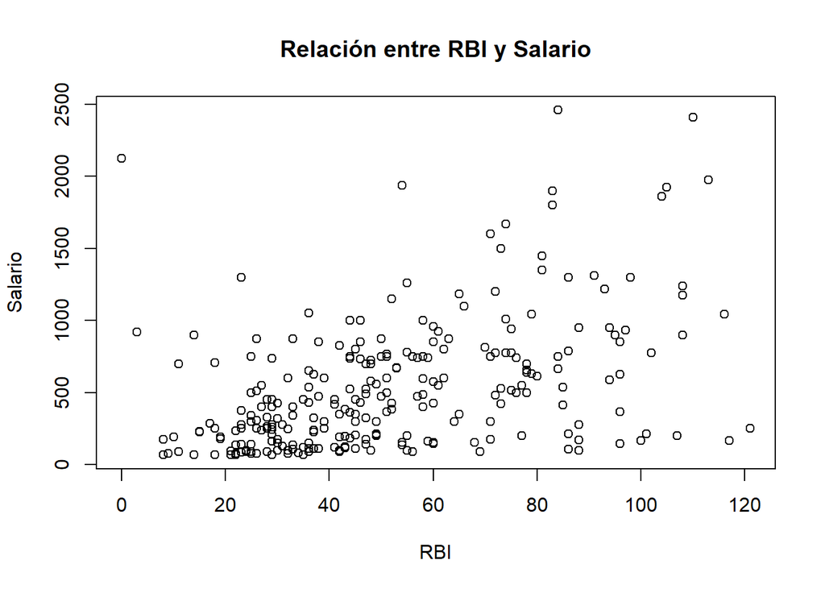

```r
plot(Hitters$RBI, Hitters$Salary,
     xlab="RBI",
     ylab="Salario",
     main="Relación entre RBI y Salario")
```

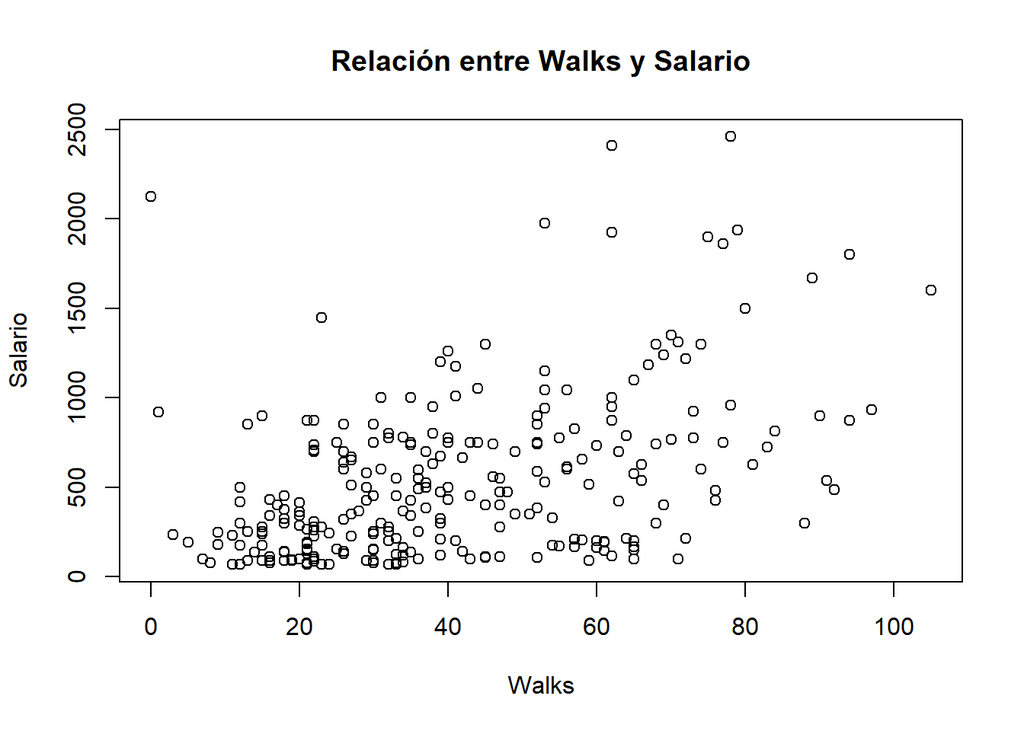

```r
plot(Hitters$Walks, Hitters$Salary,
     xlab="Walks",
     ylab="Salario",
     main="Relación entre Walks y Salario")
```

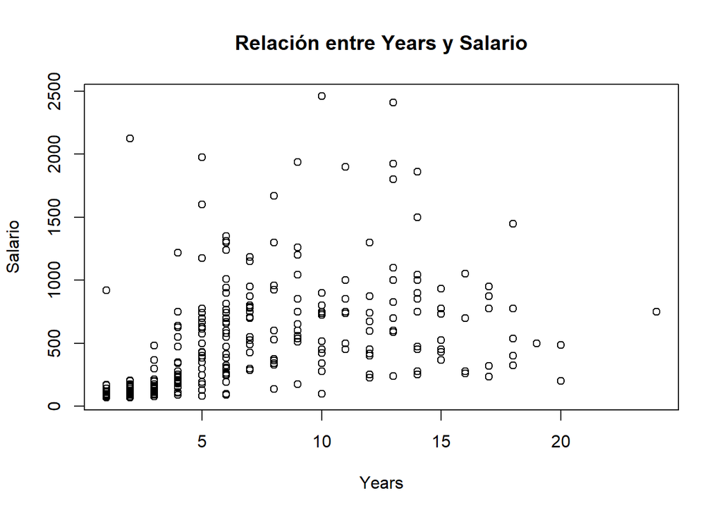

```r
plot(Hitters$Years, Hitters$Salary,
     xlab="Years",
     ylab="Salario",
     main="Relación entre Years y Salario")
```

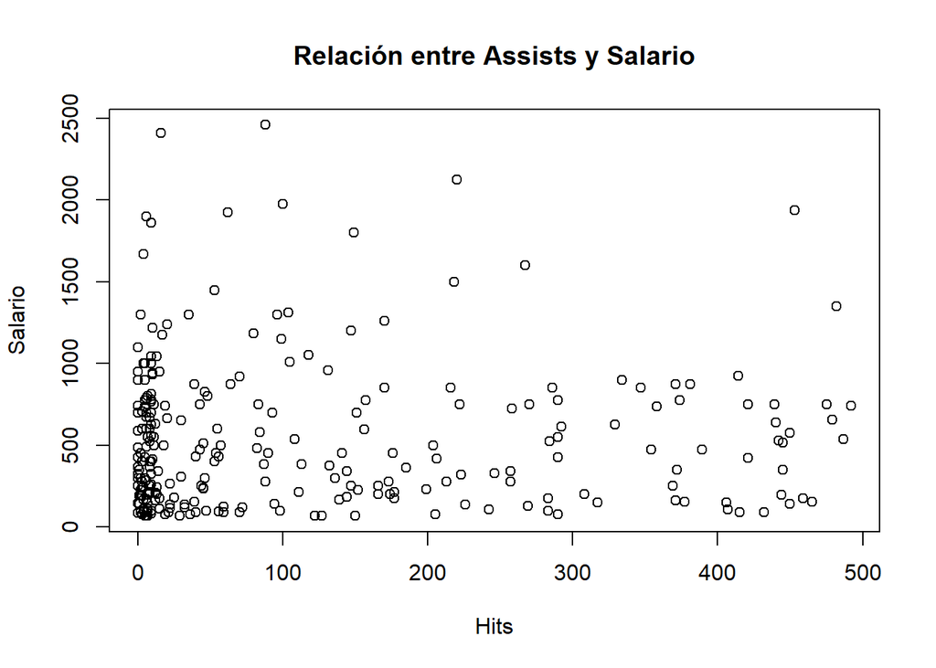

```r
plot(Hitters$Assists, Hitters$Salary,
     xlab="Hits",
     ylab="Salario",
     main="Relación entre Assists y Salario")
```

Calcular correlaciones para identificar variables más influyentes.

```r
cor_salario <- cor(Hitters[,c("AtBat","Hits","HmRun","Runs","RBI","Walks","Years","Salary")])

cor_salario[, "Salary"]
```

```
##     AtBat      Hits     HmRun      Runs       RBI     Walks     Years    Salary
## 0.3947709 0.4386747 0.3430281 0.4198586 0.4494571 0.4438673 0.4006570 1.0000000
```

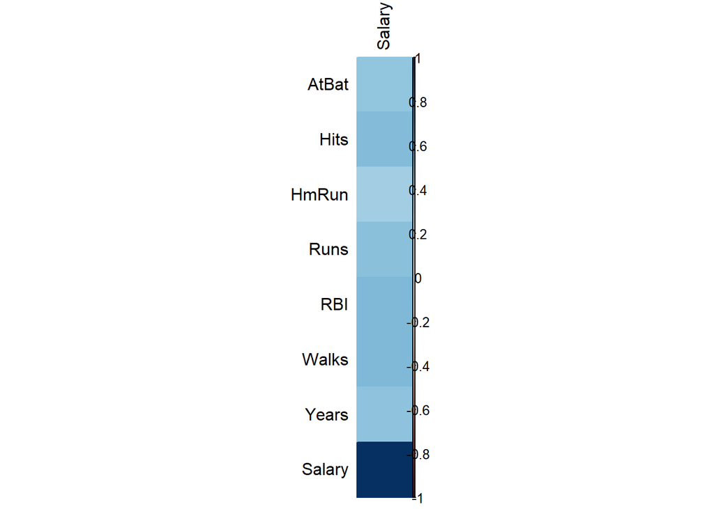

```r
library(corrplot)

cor_matrix <- cor(Hitters[,c("AtBat","Hits","HmRun","Runs","RBI","Walks","Years","Salary")])

corrplot(cor_matrix[, "Salary", drop=FALSE],
         method="color",
         tl.col="black")
```

## Manipular el modelo para desarrollar la solucion

*Ajustar el modelo de regresión múltiple y revisar:*

Coeficientes de regresión (qué variables son significativas)

R² y RMSE (para evaluar desempeño)

```r
pred <- predict(modelo_multiple)

rmse <- sqrt(mean((Hitters$Salary - pred)^2))

rmse
```

```
## [1] 353.097
```

Residuos del modelo (para verificar supuestos de linealidad y homocedasticidad)

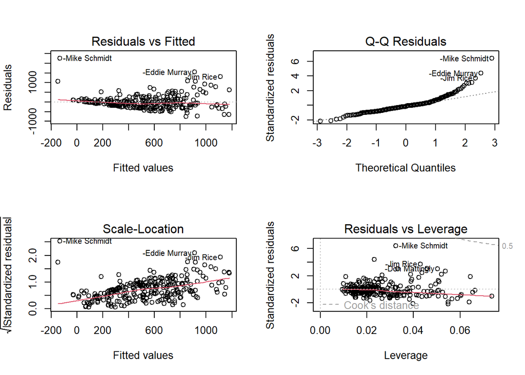

```r
par(mfrow = c(2,2))
plot(modelo_multiple)
```

**Interpretaciòn**

Los gráficos de diagnóstico del modelo de regresión muestran que, aunque el modelo explica parcialmente la relación entre las variables y el salario, existen algunas desviaciones de los supuestos del modelo. En el gráfico Residuals vs Fitted se observa cierta tendencia en los residuos, lo que sugiere posible heterocedasticidad, es decir, que la variabilidad de los errores cambia a medida que aumentan los valores predichos. El gráfico Q-Q Residuals muestra que algunos puntos se alejan de la línea teórica, indicando que los residuos no siguen perfectamente una distribución normal. En Scale-Location se aprecia que la dispersión de los residuos aumenta ligeramente, lo que también respalda la presencia de heterocedasticidad. Finalmente, el gráfico Residuals vs Leverage señala algunas observaciones influyentes, como ciertos jugadores con valores extremos, que podrían afectar la estimación del modelo. En conjunto, estos resultados sugieren que el modelo podría mejorarse aplicando transformaciones en las variables o incorporando más variables explicativas.

*Refinar el modelo:*

Eliminar variables no significativas, probar transformaciones (log(salario), sqrt(estadísticas), etc.).

```r
modelo_refinado <- step(modelo_multiple)
```

```
## Start:  AIC=3099.91
## Salary ~ Hits + HmRun + RBI + Walks + Years + League
##
##          Df Sum of Sq      RSS    AIC
## - HmRun   1      6566 32796744 3098.0
## - RBI     1     56820 32846999 3098.4
## - League  1    247785 33037964 3099.9
## <none>                32790179 3099.9
## - Hits    1    859255 33649433 3104.7
## - Walks   1   1230416 34020594 3107.6
## - Years   1   6444820 39234998 3145.1
##
## Step:  AIC=3097.96
## Salary ~ Hits + RBI + Walks + Years + League
##
##          Df Sum of Sq      RSS    AIC
## - League  1    241283 33038027 3097.9
## <none>                32796744 3098.0
## - RBI     1    277748 33074492 3098.2
## - Hits    1    975143 33771888 3103.7
## - Walks   1   1238498 34035242 3105.7
## - Years   1   6445036 39241780 3143.1
##
## Step:  AIC=3097.89
## Salary ~ Hits + RBI + Walks + Years
##
##         Df Sum of Sq      RSS    AIC
## - RBI    1    225735 33263761 3097.7
## <none>               33038027 3097.9
## - Hits   1    948335 33986362 3103.3
## - Walks  1   1305264 34343291 3106.1
## - Years  1   6403819 39441845 3142.5
##
## Step:  AIC=3097.68
## Salary ~ Hits + Walks + Years
##
##         Df Sum of Sq      RSS    AIC
## <none>               33263761 3097.7
## - Walks  1   1577939 34841700 3107.9
## - Hits   1   3242195 36505956 3120.1
## - Years  1   6971982 40235743 3145.7
```

```r
summary(modelo_refinado)
```

```
##
## Call:
## lm(formula = Salary ~ Hits + Walks + Years, data = Hitters)
##
## Residuals:
##     Min      1Q  Median      3Q     Max
## -792.74 -205.79  -44.05   94.07 2284.35
##
## Coefficients:
##              Estimate Std. Error t value Pr(>|t|)
## (Intercept) -228.9592    66.5922  -3.438 0.000682 ***
## Hits           3.0546     0.6079   5.024 9.42e-07 ***
## Walks          4.4677     1.2746   3.505 0.000538 ***
## Years         34.4420     4.6746   7.368 2.32e-12 ***
## ---
## Signif. codes:  0 '***' 0.001 '**' 0.01 '*' 0.05 '.' 0.1 ' ' 1
##
## Residual standard error: 358.4 on 259 degrees of freedom
## Multiple R-squared:  0.3761, Adjusted R-squared:  0.3689
## F-statistic: 52.05 on 3 and 259 DF,  p-value: < 2.2e-16
```

Probar transformaciones

A veces transformar variables mejora el modelo.

Log del salario

```r
modelo_log <- lm(log(Salary) ~ Hits + HmRun + RBI + Walks + Years,
                 data = Hitters)

summary(modelo_log)
```

```
##
## Call:
## lm(formula = log(Salary) ~ Hits + HmRun + RBI + Walks + Years,
##     data = Hitters)
##
## Residuals:
##     Min      1Q  Median      3Q     Max
## -2.0638 -0.4905  0.0265  0.4062  3.2315
##
## Coefficients:
##               Estimate Std. Error t value Pr(>|t|)
## (Intercept)  4.2363880  0.1182302  35.832  < 2e-16 ***
## Hits         0.0066517  0.0016429   4.049 6.82e-05 ***
## HmRun        0.0052889  0.0094004   0.563  0.57418
## RBI         -0.0006795  0.0044436  -0.153  0.87859
## Walks        0.0063121  0.0023015   2.743  0.00652 **
## Years        0.0940397  0.0084062  11.187  < 2e-16 ***
## ---
## Signif. codes:  0 '***' 0.001 '**' 0.01 '*' 0.05 '.' 0.1 ' ' 1
##
## Residual standard error: 0.635 on 257 degrees of freedom
## Multiple R-squared:  0.4998, Adjusted R-squared:   0.49
## F-statistic: 51.35 on 5 and 257 DF,  p-value: < 2.2e-16
```

Raíz cuadrada de variables

```r
modelo_sqrt <- lm(Salary ~ sqrt(Hits) + sqrt(HmRun) + Years,
                  data = Hitters)

summary(modelo_sqrt)
```

```
##
## Call:
## lm(formula = Salary ~ sqrt(Hits) + sqrt(HmRun) + Years, data = Hitters)
##
## Residuals:
##     Min      1Q  Median      3Q     Max
## -721.96 -210.61  -59.26   86.49 2457.57
##
## Coefficients:
##             Estimate Std. Error t value Pr(>|t|)
## (Intercept) -466.001    110.509  -4.217 3.43e-05 ***
## sqrt(Hits)    64.889     11.974   5.419 1.37e-07 ***
## sqrt(HmRun)   27.464     20.180   1.361    0.175
## Years         35.435      4.935   7.180 7.36e-12 ***
## ---
## Signif. codes:  0 '***' 0.001 '**' 0.01 '*' 0.05 '.' 0.1 ' ' 1
##
## Residual standard error: 378.1 on 259 degrees of freedom
## Multiple R-squared:  0.3055, Adjusted R-squared:  0.2974
## F-statistic: 37.97 on 3 and 259 DF,  p-value: < 2.2e-16
```

## Confirmar la solucion y emitir recomendaciones

Para confirmar la solución, se evalúa el desempeño del modelo de regresión analizando métricas como R², R² ajustado y RMSE, las cuales permiten determinar qué tan bien el modelo explica la variación del salario de los jugadores. Además, se revisan los residuos del modelo mediante gráficos de diagnóstico para verificar si se cumplen los supuestos de linealidad, normalidad y homocedasticidad. Si los resultados muestran que el modelo tiene un buen ajuste y errores aceptables, se considera adecuado para realizar predicciones.

Como recomendación, se sugiere utilizar regresión múltiple en lugar de regresión simple, ya que el salario de los jugadores no depende de una sola estadística sino de varias variables como Hits, Home Runs, RBI, Walks y Years. También se recomienda aplicar métodos de selección de variables o técnicas de regularización como Ridge o Lasso para mejorar la estabilidad del modelo cuando existen variables correlacionadas. Finalmente, es conveniente probar transformaciones de variables o validar el modelo con datos de entrenamiento y prueba para mejorar su capacidad predictiva y obtener estimaciones más confiables.

# Regresion logistica

## Desarollar una descripcion clara del problema

La diabetes es una enfermedad crónica que afecta a millones de personas en el mundo. Detectarla a tiempo es importante para prevenir complicaciones graves en la salud.

El objetivo de este análisis es predecir si una persona tiene diabetes o no, utilizando información médica de mujeres de la población Pima en Estados Unidos. Para ello se utilizará un modelo de regresión logística, el cual permite estimar la probabilidad de que ocurra un evento binario (en este caso, tener o no diabetes).

La base de datos utilizada es PimaIndiansDiabetes, incluida en el paquete mlbench de R, que contiene 768 observaciones y varias variables relacionadas con el estado de salud de las pacientes.

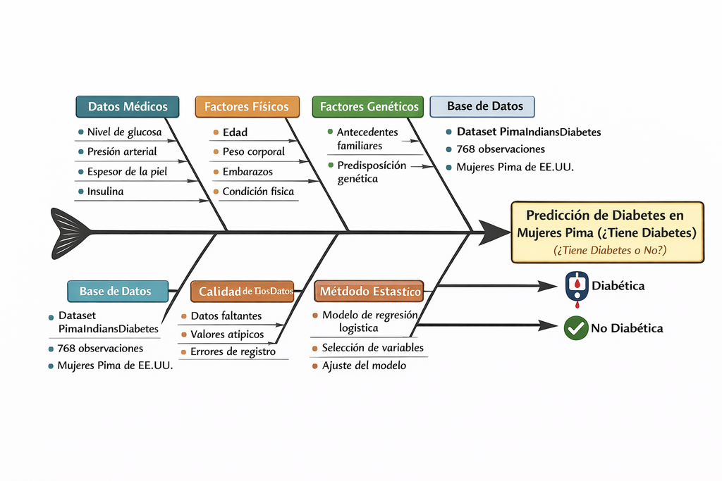

## Factores importantes

Las variables que pueden influir en la presencia de diabetes son:

*pregnant:* número de embarazos que ha tenido la paciente.

*glucose:* nivel de glucosa en la sangre.

*pressure:* presión arterial.

*triceps:* grosor del pliegue cutáneo del tríceps.

*insulin:* nivel de insulina en la sangre.

*mass:* índice de masa corporal (IMC).

*pedigree:* historial familiar de diabetes.

*age:* edad de la paciente.

Estas variables son consideradas factores explicativos que pueden ayudar a determinar la probabilidad de desarrollar diabetes.

## Proponer o refinar modelos

Para analizar el problema se propone un modelo de regresión logística donde la variable dependiente es **diabetes**.

El modelo general de regresión logística es:

$$\log \left(\frac{p}{1-p}\right) = \beta_0 + \beta_1X_1 + \beta_2X_2 +
\cdots + \beta_kX_k$$

donde:

$p$ es la probabilidad de que una persona tenga diabetes.

$X_1, X_2, ..., X_k$ representan las variables explicativas.

El modelo propuesto es:

$$diabetes \sim pregnant + glucose + pressure + insulin + mass + pedigree
+ age$$

Este modelo permite identificar qué variables influyen en la probabilidad de tener diabetes.

## Conducir experimentos y recolectar datos

Los datos provienen del dataset PimaIndiansDiabetes, que contiene información médica real de mujeres adultas.

```r
library(mlbench)

data(PimaIndiansDiabetes)
head(PimaIndiansDiabetes)
```

```
##   pregnant glucose pressure triceps insulin mass pedigree age diabetes
## 1        6     148       72      35       0 33.6    0.627  50      pos
## 2        1      85       66      29       0 26.6    0.351  31      neg
## 3        8     183       64       0       0 23.3    0.672  32      pos
## 4        1      89       66      23      94 28.1    0.167  21      neg
## 5        0     137       40      35     168 43.1    2.288  33      pos
## 6        5     116       74       0       0 25.6    0.201  30      neg
```

Luego se ajusta el modelo de regresión logística:

```r
modelo <- glm(diabetes ~ pregnant + glucose + pressure + insulin + mass + pedigree + age,
              data = PimaIndiansDiabetes,
              family = binomial)

summary(modelo)
```

```
##
## Call:
## glm(formula = diabetes ~ pregnant + glucose + pressure + insulin +
##     mass + pedigree + age, family = binomial, data = PimaIndiansDiabetes)
##
## Coefficients:
##               Estimate Std. Error z value Pr(>|z|)
## (Intercept) -8.4051362  0.7167033 -11.727  < 2e-16 ***
## pregnant     0.1231724  0.0320688   3.841 0.000123 ***
## glucose      0.0351123  0.0036625   9.587  < 2e-16 ***
## pressure    -0.0132136  0.0051537  -2.564 0.010350 *
## insulin     -0.0011570  0.0008142  -1.421 0.155275
## mass         0.0900886  0.0144619   6.229 4.68e-10 ***
## pedigree     0.9475954  0.2980063   3.180 0.001474 **
## age          0.0147888  0.0092897   1.592 0.111393
## ---
## Signif. codes:  0 '***' 0.001 '**' 0.01 '*' 0.05 '.' 0.1 ' ' 1
##
## (Dispersion parameter for binomial family taken to be 1)
##
##     Null deviance: 993.48  on 767  degrees of freedom
## Residual deviance: 723.45  on 760  degrees of freedom
## AIC: 739.45
##
## Number of Fisher Scoring iterations: 5
```

Este procedimiento permite estimar los coeficientes del modelo y analizar la significancia de cada variable.

## Manipular el modelo para desarrollar la solucion

Después de ajustar el modelo se analizan los resultados:

El modelo estimado puede expresarse como:

$$\log \left(\frac{p}{1-p}\right) =
-8.405 +
0.123(pregnant) +
0.035(glucose) -
0.013(pressure) -
0.001(insulin) +
0.090(mass) +
0.948(pedigree) +
0.015(age)$$

donde $p$ representa la probabilidad de que una persona tenga diabetes.

**Identificar variables significativas mediante el valor p-value.**

Los resultados muestran que varias variables son estadísticamente significativas en el modelo.

{glucose}: presenta un efecto positivo y altamente significativo ($p<0.001$), lo que indica que niveles más altos de glucosa aumentan la probabilidad de diabetes.

{mass}: el índice de masa corporal también tiene un efecto positivo significativo, indicando que el aumento del IMC incrementa el riesgo de diabetes.

{pregnant}: el número de embarazos muestra una relación positiva con la probabilidad de padecer diabetes.

{pedigree}: el historial familiar de diabetes también es un factor importante.

{pressure}: presenta un efecto negativo significativo, aunque menor en comparación con otras variables.

{insulin} y {age}: no resultaron estadísticamente significativas al nivel de significancia del 5%.

**Evaluar si el modelo predice correctamente la presencia de diabetes.**

```r
probabilidades <- predict(modelo, type="response")
head(probabilidades)
```

```
##          1          2          3          4          5          6
## 0.71903810 0.04824104 0.79725214 0.04158557 0.90214297 0.14758648
```

Las probabilidades obtenidas representan la probabilidad estimada de que una paciente tenga diabetes según sus características médicas.

Por ejemplo:

La observación 1 tiene una probabilidad de $0.719$, lo que indica un 71.9% de probabilidad de presentar diabetes.

La observación 2 tiene una probabilidad de $0.048$, lo que representa una probabilidad muy baja de padecer diabetes.

La observación 5 presenta una probabilidad de $0.902$, lo que indica un riesgo muy alto de diabetes.

En modelos de regresión logística generalmente se utiliza un punto de corte de $0.5$ para clasificar los resultados:

Si $p > 0.5$ se clasifica como {diabetes positiva}. Si $p < 0.5$ se clasifica como {diabetes negativa}.

De esta manera el modelo puede utilizarse para predecir y clasificar nuevas observaciones según el riesgo de padecer diabetes.

**Eliminar variables poco relevantes para mejorar el modelo.**

```r
modelo1 <- glm(diabetes ~ pregnant + glucose  + mass + pedigree ,
              data = PimaIndiansDiabetes,
              family = binomial)

summary(modelo)
```

```
##
## Call:
## glm(formula = diabetes ~ pregnant + glucose + pressure + insulin +
##     mass + pedigree + age, family = binomial, data = PimaIndiansDiabetes)
##
## Coefficients:
##               Estimate Std. Error z value Pr(>|z|)
## (Intercept) -8.4051362  0.7167033 -11.727  < 2e-16 ***
## pregnant     0.1231724  0.0320688   3.841 0.000123 ***
## glucose      0.0351123  0.0036625   9.587  < 2e-16 ***
## pressure    -0.0132136  0.0051537  -2.564 0.010350 *
## insulin     -0.0011570  0.0008142  -1.421 0.155275
## mass         0.0900886  0.0144619   6.229 4.68e-10 ***
## pedigree     0.9475954  0.2980063   3.180 0.001474 **
## age          0.0147888  0.0092897   1.592 0.111393
## ---
## Signif. codes:  0 '***' 0.001 '**' 0.01 '*' 0.05 '.' 0.1 ' ' 1
##
## (Dispersion parameter for binomial family taken to be 1)
##
##     Null deviance: 993.48  on 767  degrees of freedom
## Residual deviance: 723.45  on 760  degrees of freedom
## AIC: 739.45
##
## Number of Fisher Scoring iterations: 5
```

```r
probabilidades <- predict(modelo1, type="response")
head(probabilidades)
```

```
##          1          2          3          4          5          6
## 0.65275605 0.04720267 0.79168475 0.05125442 0.83841714 0.16771338
```

```r
# Clasificación
prediccion <- ifelse(probabilidades > 0.5, "pos", "neg")
table(prediccion)
```

```
## prediccion
## neg pos
## 559 209
```

```r
head(prediccion)
```

```
##     1     2     3     4     5     6
## "pos" "neg" "pos" "neg" "pos" "neg"
```

```r
# Matriz de confusión
matriz <- table(Predicho = prediccion,
                Real = PimaIndiansDiabetes$diabetes)

matriz
```

```
##         Real
## Predicho neg pos
##      neg 442 117
##      pos  58 151
```

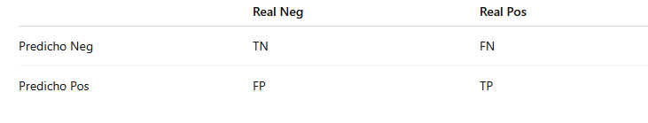

donde:

TP → verdaderos positivos

TN → verdaderos negativos

FP → falsos positivos

FN → falsos negativos

**Exactitud del modelo**

La exactitud mide la proporción de observaciones correctamente clasificadas por el modelo y se calcula mediante:

$$Accuracy = \frac{TP + TN}{Total}$$

Un valor alto de exactitud indica que el modelo tiene una buena capacidad de clasificación para predecir la presencia de diabetes.

```r
# Exactitud
exactitud <- sum(diag(matriz)) / sum(matriz)

exactitud
```

```
## [1] 0.7721354
```

Sensibilidad

La sensibilidad mide la capacidad del modelo para identificar correctamente los casos positivos (pacientes con diabetes).

$$Sensibilidad = \frac{TP}{TP + FN}$$

```r
TP <- 151
FN <- 117

sensibilidad <- TP/(TP+FN)

sensibilidad
```

```
## [1] 0.5634328
```

Esto significa que el modelo identifica correctamente el 56.34% de los pacientes con diabetes.

Especificidad

La especificidad mide la capacidad del modelo para identificar correctamente los casos negativos.

$$Especificidad = \frac{TN}{TN + FP}$$

```r
TN <- 442
FP <- 58

especificidad <- TN/(TN+FP)

especificidad
```

```
## [1] 0.884
```

Esto indica que el modelo clasifica correctamente el 88.4% de los pacientes sin diabetes.

**Curva ROC y AUC**

La curva ROC permite evaluar el desempeño del modelo para diferentes puntos de corte. El área bajo la curva (AUC) mide la capacidad del modelo para diferenciar entre pacientes con y sin diabetes.

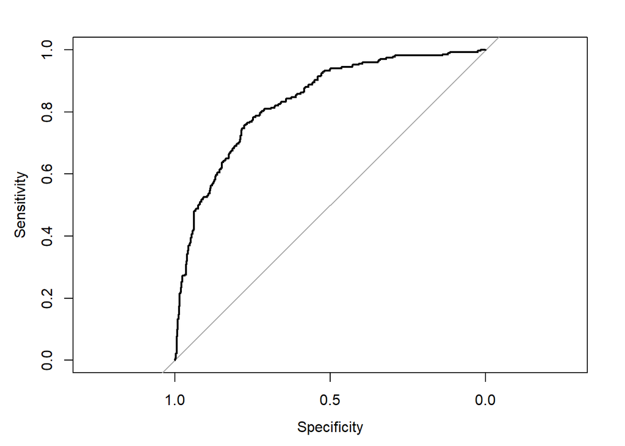

```r
library(pROC)

roc_modelo <- roc(PimaIndiansDiabetes$diabetes, probabilidades)

plot(roc_modelo)
```

```r
auc(roc_modelo)
```

```
## Area under the curve: 0.8345
```

Un valor de AUC cercano a 1 indica un modelo con excelente capacidad predictiva, mientras que valores cercanos a 0.5 indican un modelo sin capacidad discriminatoria.

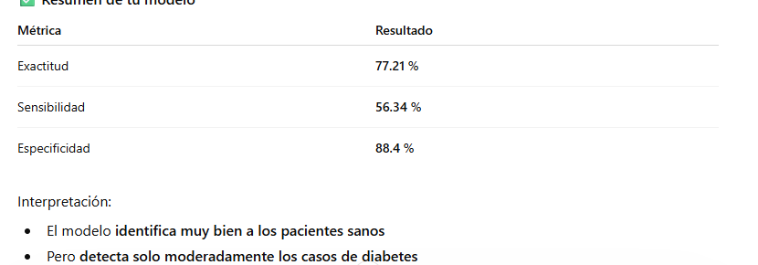

## Confirmar la solucion y emitir recomendaciones

Para validar el modelo de regresión logística se analizaron diferentes métricas de desempeño obtenidas a partir de la matriz de confusión.

El modelo obtuvo una exactitud de 77.21%, lo que indica que aproximadamente el 77% de las observaciones fueron clasificadas correctamente. Este resultado muestra que el modelo tiene una capacidad aceptable para predecir la presencia de diabetes.

En cuanto a las métricas de clasificación:

Sensibilidad: 56.34%. Esto significa que el modelo logra identificar correctamente el 56% de los pacientes que realmente tienen diabetes.

Especificidad: 88.4%. Esto indica que el modelo clasifica correctamente el 88% de los pacientes que no presentan diabetes.

Estos resultados muestran que el modelo es más preciso para identificar pacientes sin diabetes que para detectar pacientes con la enfermedad. Esto puede deberse a que algunos casos positivos presentan características similares a los negativos.

Conclusiones

El modelo de regresión logística permite analizar la relación entre diferentes variables médicas y la probabilidad de padecer diabetes. Variables como el nivel de glucosa, el índice de masa corporal y el historial familiar mostraron una influencia importante en la predicción de la enfermedad.

En general, el modelo presenta un desempeño aceptable y puede utilizarse como herramienta de apoyo para la identificación temprana de pacientes con riesgo de diabetes.

Recomendaciones

Realizar monitoreo frecuente de los niveles de glucosa en la sangre, ya que esta variable tiene una fuerte relación con la presencia de diabetes.

Promover hábitos de vida saludables que ayuden a mantener un índice de masa corporal adecuado.

Realizar evaluaciones médicas periódicas especialmente en personas con antecedentes familiares de diabetes.

Mejorar el modelo incorporando más variables clínicas o utilizando técnicas adicionales de aprendizaje automático para aumentar la sensibilidad del modelo.

El uso de modelos estadísticos como la regresión logística puede contribuir a la toma de decisiones médicas y a la prevención de enfermedades mediante la identificación temprana de factores de riesgo.